# PML Course Project

SB

12/10/2020

```r
library(caret)
library(rpart)
library(rpart.plot)
library(randomForest)
set.seed(12345)
```

## Project Goal

This project aims to predict how well barbell lifts are performed using data from accelerometers on the belt, forearm, arm, and dumbell of 6 participants. The participants were asked to perform the barbell lifts correctly and incorrectly in five different ways. The manner in which the exercise was performed is recorded in the “classe” variable in the dataset.

## Loading and Cleaning the Dataset

```
## [1] 19622   160
```

```
## [1]  20 160
```

## Approach to Cross Validation and Assessing Out-of-Sample Error

Since the sample size is quite large (19622), 70% of the samples were subsetted for training the model and 30% for validating the model. Model predictions of performance will be evaluated against this validation set and the model that maximizes accuracy and minimizes out-of-sample error will be selected. The out-of-sample error is expected to equal 1-accuracy in the cross-validation data.

```r
inTrain = createDataPartition(y=training_new$classe, p=0.7, list=FALSE)
trainset = training_new[inTrain,]
validation = training_new[-inTrain,]
dim(trainset); dim(validation)
```

```
## [1] 13737    53
```

```
## [1] 5885   53
```

## Exploring the Training Set

Figure 1 shows the distribution of the outcome variable “classe”, a factor variable with 5 levels. Class A corresponds to the exercise being performed exactly according to the specification, class B corresponds to throwing the elbows to the front, class C corresponds to lifting the dumbbell only halfway, class D corresponds to lowering the dumbbell only halfway, and class E corresponds to throwing the hips to the front.

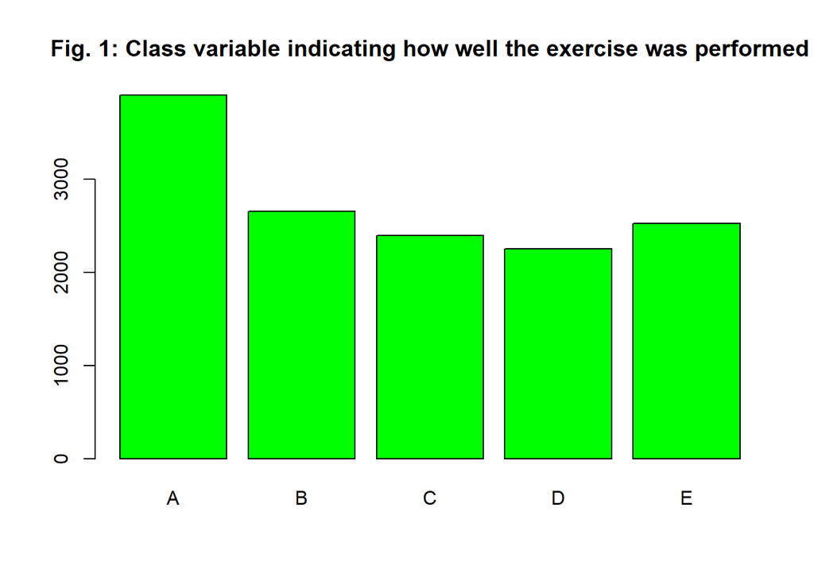

## Building the Model

The following two models were chosen for consideration because they are applicable to factor variables: predicting with trees and random forest.

**Predicting with trees**

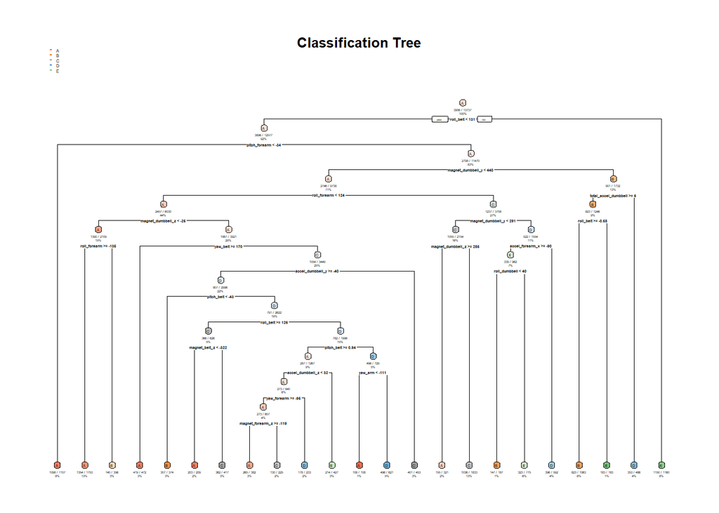

```r
mod_tree = rpart(classe~., data=trainset, method = "class")
rpart.plot(mod_tree, main="Classification Tree", extra=102, under=TRUE, faclen=0)
```

```r
pred_tree = predict(mod_tree, validation, type="class")
# check model accuracy
confusionMatrix(pred_tree, validation$classe)
```

```
## Confusion Matrix and Statistics
##
##           Reference
## Prediction    A    B    C    D    E
##          A 1532  176   28   48   41
##          B   54  585   57   64   76
##          C   35  154  819  134  126
##          D   25   76   58  631   56
##          E   28  148   64   87  783
##
## Overall Statistics
##
##                Accuracy : 0.7392
##                  95% CI : (0.7277, 0.7503)
##     No Information Rate : 0.2845
##     P-Value [Acc > NIR] : < 2.2e-16
##
##                   Kappa : 0.6692
##
##  Mcnemar's Test P-Value : < 2.2e-16
##
## Statistics by Class:
##
##                      Class: A Class: B Class: C Class: D Class: E
## Sensitivity            0.9152  0.51361   0.7982   0.6546   0.7237
## Specificity            0.9304  0.94711   0.9076   0.9563   0.9319
## Pos Pred Value         0.8395  0.69976   0.6459   0.7459   0.7054
## Neg Pred Value         0.9650  0.89028   0.9552   0.9339   0.9374
## Prevalence             0.2845  0.19354   0.1743   0.1638   0.1839
## Detection Rate         0.2603  0.09941   0.1392   0.1072   0.1331
## Detection Prevalence   0.3101  0.14206   0.2155   0.1438   0.1886
## Balanced Accuracy      0.9228  0.73036   0.8529   0.8054   0.8278
```

The decision tree model has an accuracy of 0.7392 and estimated out-of-sample error of 0.2608.

**Random forest**

```r
mod_rf = randomForest(classe~., data=trainset, method="class")
pred_rf = predict(mod_rf, validation, type="class")
# check model accuracty
confusionMatrix(pred_rf, validation$classe)
```

```
## Confusion Matrix and Statistics
##
##           Reference
## Prediction    A    B    C    D    E
##          A 1673    3    0    0    0
##          B    1 1135    4    0    0
##          C    0    1 1022   10    0
##          D    0    0    0  954    1
##          E    0    0    0    0 1081
##
## Overall Statistics
##
##                Accuracy : 0.9966
##                  95% CI : (0.9948, 0.9979)
##     No Information Rate : 0.2845
##     P-Value [Acc > NIR] : < 2.2e-16
##
##                   Kappa : 0.9957
##
##  Mcnemar's Test P-Value : NA
##
## Statistics by Class:
##
##                      Class: A Class: B Class: C Class: D Class: E
## Sensitivity            0.9994   0.9965   0.9961   0.9896   0.9991
## Specificity            0.9993   0.9989   0.9977   0.9998   1.0000
## Pos Pred Value         0.9982   0.9956   0.9894   0.9990   1.0000
## Neg Pred Value         0.9998   0.9992   0.9992   0.9980   0.9998
## Prevalence             0.2845   0.1935   0.1743   0.1638   0.1839
## Detection Rate         0.2843   0.1929   0.1737   0.1621   0.1837
## Detection Prevalence   0.2848   0.1937   0.1755   0.1623   0.1837
## Balanced Accuracy      0.9993   0.9977   0.9969   0.9947   0.9995
```

The random forest model has an accuracy of 0.9966 and estimated out-of-sample error of 0.0034.

Therefore, the random forest model was chosen because it performs best on the validation data.

## Prediction Using the Original Testing Dataset

The random forest model was used to predict the 20 test cases provided.

```r
predict(mod_rf, testing, type="class")
```

```
##  1  2  3  4  5  6  7  8  9 10 11 12 13 14 15 16 17 18 19 20
##  B  A  B  A  A  E  D  B  A  A  B  C  B  A  E  E  A  B  B  B
## Levels: A B C D E
```